# 常用统计检验方法总结

## 5.7 Kruskal-Wallis检验

**目的**

- 检验多个（≥2）独立样本：是否来自相同的总体，或者说这些样本在中位数或总体位置上是否相同

**适用**

- 检验类型：非参数检验（多组独立样本比较，无需正态分布）
- 数据类型：数值数据或序数数据
- 数据体量：小样本或多组比较（ANOVA的非参数替代）

**计算公式**

- 统计量$H=\frac{12}{N(N+1)}\sum_{i=1}^k\frac{R_i^2}{n_i}-3(N+1)$
- ties修正统计量$H_{cor}=\frac{H}{1-\frac{\sum_j{(t_j^3-t_j)}}{N^3-N}}$
- 自由度$df=k-1$

其中：

- $k$，组数
- $N$，所有样本数（将多组数据汇总为一个数据后的）
- $n_i$，第i组的样本书来给你
- $R_i$，第i组的总秩和（多组数据汇总后求秩，然后将秩按组提取）
- $t_1,t_2,...,t_j$为ties，对应合并数据中非重复值对应的频数

**结果判定**

统计量H近似服从自由度为k-1的卡方分布，设定显著性水平为α，检验结果判定步骤如下（Kruskal-Wallis检验原假设只有≠一种形式）：

H0：所有组的总体分布相同（当已知同分布时，为中位数全相等）vs. H1：至少有一个组的总体分布与其他不同（已知同分布时，中位数不全相等）

1. $p=P(X\geq H)$
2. 拒绝域$H \geq \chi^2_{1-\alpha,df}$

**案例**

R语言中，使用`stats::kruskal.test`函数执行Kruskal-Wallis检验。

比较三种不同教学方法（方法A、B、C）对学生考试成绩的影响，收集的数据为各方法下学生的考试成绩，这些成绩可能不满足正态分布，所以不能用ANOVA，而采用Kruskal-Wallis检验。

A:c(70,75,80,65,78,73,76,81), B:c(88,85,90,87,91,80,79), C:c(60,63,58,66,62,90,88)

```r
# 加载包
library(magrittr)

# 设定显著性水平α=0.05
a <- 0.05

# 数据
A <- c(70,75,80,65,78,73,76,81)
B <- c(88,85,90,87,91,80,79)
C <- c(60,63,58,66,62,90,88)

dat <- data.frame(
  score = c(A, B, C),
  method = factor(c(rep("A",length(A)),rep("B",length(B)),rep("C",length(C))))
)

# 函数计算.................................................................................
test.1 <- kruskal.test(score ~ method, data = dat)
# 结果如下，p-value < a，表明拒绝H0，认为不同方法下的成绩有差异
#   Kruskal-Wallis rank sum test
# data:  score by method
# Kruskal-Wallis chi-squared = 7.9097, df = 2, p-value = 0.01916
# 手工计算.................................................................................
# 数据
A <- c(70,75,80,65,78,73,76,81)
B <- c(88,85,90,87,91,80,79)
C <- c(60,63,58,66,62,90,88)
df <- 3-1
nA <- length(A)
nB <- length(B)
nC <- length(C)
N <- nA+nB+nC
ABC <- c(A,B,C)
RABC <- rank(ABC)
RA <- RABC[1:nA] %>% sum()
RB <- RABC[(nA+1):(nA+nB)] %>% sum()
RC <- RABC[(nA+nB+1):(nA+nB+nC)] %>% sum()
ties <- table(ABC)                                   #记录ties
H <- 12/N/(N+1)*(RA^2/nA+RB^2/nB+RC^2/nC)-3*(N+1)
Hcor <- H/(1-sum(ties^3-ties)/(N^3-N))               #Hcor=7.909679

# 计算双侧检验p值
p <- 1-pchisq(Hcor, df)              #p=0.01916174

# 计算拒绝域临界值
thes <-  qchisq(1-0.05, df)          #thes=5.991465

# 结果表明：p<a，Z>thres，因此拒绝H0，认为不同方法下的成绩有差异
```

## 5.8 Kolmogorov-Smirnov检验

又叫KS检验

**目的**

一种基于累积分布函数（CDF）差异的检验方法，主要用于：

- 检验单样本：是否来自某个特定的理论分布（如正态分布、指数分布等）
- 检验两个独立样本：否来自同一分布

注意：

- 数据分布参数由样本估计（如正态分布的均值和方差），需使用Lilliefors修正
- 对离散数据或高维数据，可考虑卡方检验或Anderson-Darling检验

**适用**

- 检验类型：非参数检验（比较分布函数，无参数假设）。
- 数据类型：数值数据（虽然也有对离散变量的扩展方法）
- 数据体量：小样本或大样本均可（但大样本对微小差异更敏感，易拒绝H0）。

**计算公式**

单样本统计量：$D_m=sup_x|F_m(x)-F(x)|$

两样本统计量：$D_{m,n}=sup_x|F_{1,m}(x)-F_{2,n}(x)|$

其中：

1. 原数据应先进行升序排列：$x_1,x_2,x_3,...,x_n$升序排列为$x_{(1)},x_{(2)},x_{(3)},...,x_{(n)}$
2. 样本检验分布函数ECDF：$F_m(x)=\frac{样本中小于等于x的数据点的数量}{m}$
3. 参考分布函数CDF：$F(x)$

**结果判定**

H0：数据服从给定分布（单样本）或H0：两数据分布相同（双样本）

通常靠查表计算拒绝域临界值、蒙特卡洛模拟或大样本下的近似公式：$p\approx2exp(-2nD^2)$

**案例**

R语言中，使用`stats::ks.test`函数执行KS检验，其中参数如下：

- `x`：第一组数据（数值向量），用于造经验分布函数
- `y`：第二组数据（双样本检验时提供），或者是字符串，如”pnorm”、“pexp” 等（用于单样本检验时）
- `alternative`：备择假设的方向，默认”two.sided”，可选”less”或”greater”，经验分布大于理论分布的关系
- `exact`：是否使用精确 p 值计算，TRUE对双样本、样本较小、且没有重复值时有效，FALSE：使用渐进方法（大样本近似）；NULL（默认），自动判断是否可以使用精确法
- `simulate.p.value`：是否使用模拟（bootstrap）方式来计算p值，适用于样本小、重复值多、exact不可用时
- `B`：当simulate.p.value=TRUE 时，指定模拟的重复次数，默认是 B = 2000

案例1，单样本检验：检验样本是否服从特定参数的正态分布

```r
# 设定显著性水平α=0.05
a <- 0.05

# 生成样本数据
set.seed(123)
sample_data <- rnorm(100, mean = 0, sd = 1) + rt(100, 3)

# 执行KS检验（H0: 样本服从均值为3方差为1的正态分布，注意，如果不指定，则默认mean=0sd=1即标准正态分布）
test.1 <- ks.test(sample_data, "pnorm", mean = 3, sd = 1)
# 结果如下：证明p-value < a，说明拒绝原假设，认为数据不服从均值为3方差为1的正态分布
#   Asymptotic one-sample Kolmogorov-Smirnov test
# data:  sample_data
# D = 0.81903, p-value < 2.2e-16
# alternative hypothesis: two-sided
```

案例2，两样本检验：判断两个样本是否来自同一个分布

```r
# 设定显著性水平α=0.05
a <- 0.05

# 生成两个样本
set.seed(123)
sample1 <- rnorm(100, mean = 0, sd = 1)
sample2 <- rnorm(100, mean = 1, sd = 1)

# 执行双样本KS检验
test.2 <- ks.test(sample1, sample2)
# 结果如下：证明p-value < a，说明拒绝原假设，认为两数据不来自于同一主体（两数据分布不同）
#   Asymptotic two-sample Kolmogorov-Smirnov test
# data:  sample1 and sample2
# D = 0.37, p-value = 2.267e-06
# alternative hypothesis: two-sided
```

## 5.9 Lilliefors检验

又叫LI检验，是Kolmogorov-Smirnov（KS）检验的改进版本

**目的**

基于经验分布函数（EDF）与假设的理论分布函数：

- 检验某个样本：否来自某个理论分布（尤其是正态分布），评估数据对分布的偏离程度

**适用**

- 检验类型：非参数检验（改进的KS检验，自动估计正态分布参数）
- 数据类型：数值数据（连续型）
- 数据体量：小样本或大样本均可（比KS检验更适用于正态性检验）
- 与SW检验相比，LI检验对非正态性更敏感，尤其在尾部偏离时表现更好，但Shapiro-Wilk检验在小样本中功效更高
- 与K-S检验相比，而LI检验检分布时，不需要制定理论分布的参数（如均值方差），直接使用样本估计的均值和方差，因此更适用于参数未知的情况

**计算公式**

1. 估计样本均值和标准差：$\hat \mu = \frac{1}{n}\sum_{i=1}^n{x_i}$，$\hat\sigma=\sqrt{\frac{1}{n}\sum_{i=1}^{n}{(x_i-\hat\mu)^2}}$
2. 样本标准化：$z_i=\frac{x_i-\hat\mu}{\hat\sigma}$
3. 经验分布函数（EDF排序后数据）：$F_n(z_{(i)})=\frac{i}{n}$
4. 理论分布函数（CDF）：$\Phi(z_i)=\int_{-\infty}^{z_i}{\frac{1}{\sqrt{2\pi}}e^{-t^2/2}dt}$
5. 统计量D：$D=max(|F_n(z_i)-\Phi(z_i)|, |F_n(z_i)-\Phi(z_{i-1})|)$

**结果判定**

H0：数据服从正态分布 vs. H1：数据不服从正态分布

通常靠查表或者使用软件计算

**案例**

在R语言中，通过`nortest::lillie.test`执行LI检验，该函数只有一个参数x，代表被测数据

```r
# 设定显著性水平α=0.05
a <- 0.05

# 加载包
library(nortest)

# 生成样本数据
set.seed(123)
sample_data <- rnorm(100, mean = 31, sd = 1)

# 执行LI检验（H0: 样本服从正态分布）
test.1 <- lillie.test(sample_data)
# 结果如下：证明p-value > a，说明不拒绝原假设，认为数据服从正态分布
#   Lilliefors (Kolmogorov-Smirnov) normality test
# data:  sample_data
# D = 0.058097, p-value = 0.5575
```

## 5.10 Anderson-Darling检验

又叫AD检验，是Kolmogorov-Smirnov（KS）检验的改进版本

**目的**

- 检验某个样本：是否来自某个特定分布（常用正态分布）
- 本质是比较样本的经验分布函数（EDF）与理论分布函数（CDF）之间的差异，但对两端（尾部）的偏离赋予更高的权重。

**适用**

- 检验类型：非参数检验
- 数据类型：数值数据（连续型）
- 数据体量：适用于中小样本，也可用于大样本

**计算公式**

1. 原数据应先进行升序排列：$x_1,x_2,x_3,...,x_n$升序排列为$x_{(1)},x_{(2)},x_{(3)},...,x_{(n)}$
2. 统计量$A^2=-n-\frac{1}{n}\sum_{i=1}^n{[(2i-1)(lnF(x_{(i)})+ln(1-F(x_{(n+1-i)})))]}$
3. 其中$F(x)$为理论CDF函数

**结果判定**

H0：样本来自指定的理论分布（例如正态分布）

通常靠查表或者使用软件计算

**案例**

在R语言中，通过`nortest::ad.test`执行AD检验，该函数只用于检验数据是否符合正态分布，且只有一个参数x，代表被测数据

```r
# 设定显著性水平α=0.05
a <- 0.05

# 加载包
library(nortest)

# 生成样本数据
set.seed(123)
sample_data <- rnorm(100, mean = 31, sd = 1)

# 执行AD检验（H0: 样本服从正态分布）
test.1 <- ad.test(sample_data)
# 结果如下：证明p-value > a，说明不拒绝原假设，认为数据服从正态分布
#   Anderson-Darling normality test
# data:  sample_data
# A = 0.182, p-value = 0.9104
```

## 5.11 Shapiro-Wilk检验

又叫SW检验

**目的**

通过比较样本数据与理想正态数据的分位数相关性：

- 检验某个样本：否服从正态分布

**适用**

- 检验类型：参数检验（专用于正态性检验，依赖样本参数估计）
- 数据类型：数值数据（连续型）
- 数据体量：小样本n<50 时最优，大样本可能过于敏感（若数据离散或含大量重复值，检验功效可能降低）
- 分布对称性：对非对称分布（如偏态分布）的检测效果优于其他正态性检验（如K-S检验）

**计算公式**

统计量$W=\frac{(\sum_{i=1}^n{a_ix_{(i)}})^2}{\sum_{i=1}^n{(x_i-\bar x})^2}$

其中：$x_{(i)}$，样本数据排序后的第个数据；$a_i$，有正态分布期望值生成的系数

**结果判定**

H0：数据服从正态分布 vs. H1：数据不服从正态分布

W值越接近1，样本越可能服从正态分布；显著小于1则偏离正态

**案例**

R语言中，使用`stats::shapiro.test`执行SW检验，只有一个参数x（可以添加均值方差），要求是x中不能有缺失值、长度在3到5000之间

```r
# 设定显著性水平α=0.05
a <- 0.05

# 生成样本数据
set.seed(123)
sample_data <- rnorm(100, mean = 31, sd = 1)

# 执行SW检验（H0: 样本服从正态分布）
test.1 <- shapiro.test(sample_data)
# 结果如下：证明p-value > a，说明不拒绝原假设，认为数据服从正态分布
#   Shapiro-Wilk normality test
# data:  sample_data
# W = 0.99626, p-value = 0.9954
```

## 5.12 方差分析

英文名Analysis of Variance，ANOVA

**目的**

通过方差分解，检验多组数据的：组间均值是否相同

具体来说，ANOVA将总体方差分解为组间均方（Mean Square Between, MSB）和组内均方（Mean Square Within, MSW）。其中，组间均方MSB衡量各组均值相对整体均值的离散程度，而组内均方MSW描述组内数据相对组内均值的离散程度（很多情况下，组内差异也被称为残差，Residuals）。这样，如果MSB很大，说明各组均值差异显著，而如果MSW很大，说明组内本身分布不均匀。而ANOVA就是在判断，当前观察到的“组间偏差”，是否远大于可以归因于“随机组内波动”的程度？换句话说，你们之间的差异，是因为你们本来就不同，还是只是偶然的观测波动。

注意：

- ANOVA的核心是F检验，但其前提、后续涉及多个检验方法，这里重点是在案例中演示R语言进行ANOVA的详细流程
- ANOVA的本质是线性回归的特例，即当自变量全是分类变量时，回归模型等价于方差分析
- 可以先做回归再做方差分析，例如`rstatix::anova_test`的例子`anova_test(lm(yield ~ block + N*P*K, npk))`，类似的，可利用回归分析+ANOVA，处理混合变量类型（连续+分类）、非平衡设计（各组样本量不等）、复杂模型结构（随机效应、非线性项）等问题

此外，还有很多扩展的方差分析，这里不做一一介绍：

1. 重复测量方差分析：让同一组受试者在不同时间点或条件下进行多次测量时使用
2. 混合设计方差分析：结合了“重复测量方差分析”和“多因素方差分析”的特点，适用于有重复测量因素和独立因素的混合设计
3. 方差分析与加权法：为不同组别赋予不同权重的方差分析，常用于组别大小不一致的情况
4. 随机效应方差分析：与固定效应模型不同，随机效应模型假设因子水平是随机选取的，且试图分析这些随机因素对因变量的影响
5. 多重响应变量的方差分析：MANOVA是ANOVA的扩展，允许同时分析多个相关的因变量，通过多元正态分布来评估组间的差异
6. 路径分析与结构方程模型中的方差分析：在结构方程模型（SEM）中，方差分析的思想被用于分析因变量与自变量之间的关系，尤其是在多因子模型中
7. 协方差分析（ANCOVA）：基础的ANOVA自变量都是分类型，如果额外加入数值型自变量作为协变量（只是限制因素，并不参与结果分析），则为协方差分析

**适用**

- 检验类型：参数检验，要求正态性、方差齐性
- 数据类型：因变量为数值型，自变量为分类型（2组或多组）
- 数据体量：建议各组样本量 ≥ 5（多因素时还包括交互组），总体样本量 ≥ 20

注意，常规ANOVA，以及不满足条件时的下替代方案，如下表所示：

| 方法 | 正态? | 方差齐次? | 多因素? | 交互? |
| --- | --- | --- | --- | --- |
| 1.ANOVA | ✅ | ✅ | ✅ | ✅ |
| 2.Welch’s ANOVA | ✅ | ❌ | ❌ | ❌ |
| 3.非参数检验 | ❌ | ❌ | ❌ | ❌ |
| 4.非参数多因素扩展 | ❌ | ❌ | ✅ | ✅ |
| 5.稳健单因素ANOVA | ❌ | ❌ | ❌ | ❌ |
| 6.稳健多因素ANOVA | ❌ | ❌ | ✅ | ✅ |

其中：

- 单因素Welch’s ANOVA，可用于方差非齐次、未知、甚至齐次（此时结果与普通ANOVA相接近）
- 多因素时，每个因子的不同水平组合都可能拥有不同的方差，且主效应、交互效应不再独立，异方差会扭曲交互结构
- 除方差分析或非参数检验，还可以用广义最小二乘法（`nlme::gls` + `varIdent`）或者文件线性模型（`lm` + `sandwich::vcovHC`）来进行非正态、非齐次下的多因素、交互效应对比

**计算公式（单因素方差分析）**

- 统计量：$F=\frac{MSB}{MSW}=\frac{SSB/(k-1)}{SSW/(N-k)}$
- 组间均方（Mean Square Between, MSB）：$MSB=\frac{\sum^{k}_{i=1}{n_i(\bar X_i-\bar X)^2}}{k-1}$
- 组内均方（Mean Square Within, MSW）：$MSW=\frac{\sum_{i=1}^{k}{\sum_{j=1}^{n_i}{(X_{ij}-\bar X_i)^2}}}{N-k}$
- 自由度：组间（分子）$df_1=k-1$，组内（分母）$df_2=N-k$
- $k$，组数：$n_i$，第i组的样本量；$N=\sum n_i$，总样本量；$\bar X_i$，第i组的样本均值，$\bar X$，总体均值

注意：

- 计算MSB时，乘以$n_i$是为了反映每组在总体中的代表性或权重，即组的样本量越大，它的均值对整体的贡献越大，偏离总体均值所造成的变异也越大。

**结果判定**

统计量F服从自由度为$df=(k-1,N-k)$的F分布。设定显著性水平为α后，结果判定步骤如下：

1. 方差分析只有双侧检验，即H0: $\mu_1=\mu_2=...=\mu_k$ vs. H1：$\mu_i$不全相等
2. $p=2 \times min(P(X \geq F), P(X \leq F))$，拒绝域为$F \leq F_{\alpha /2}(k-1,N-k)$ 或 $F \geq F_{1-\alpha/2}(k-1,N-k)$
3. 如果$p<\alpha$或F落在拒绝域内，则拒绝H0

### 案例

案例方法按如下表格：

| 方法 | 正态? | 方差齐次? | 多因素? | 交互? |
| --- | --- | --- | --- | --- |
| 案例1.ANOVA | ✅ | ✅ | ✅ | ✅ |
| 案例2.Welch’s ANOVA | ✅ | ❌ | ❌ | ❌ |
| 案例3.非参数检验 | ❌ | ❌ | ❌ | ❌ |
| 案例4.非参数多因素扩展 | ❌ | ❌ | ✅ | ✅ |
| 案例5.稳健单因素ANOVA | ❌ | ❌ | ❌ | ❌ |
| 案例5.稳健多因素ANOVA | ❌ | ❌ | ✅ | ✅ |

**总结：ANOVA流程与R函数**：

1. 正态性检验
   - Shapiro-Wilk检验（推荐）：`satats::shapiro.test`
   - Lilliefors检验： `nortest::lillie.test`
   - Anderson-Darling检验： `nortest::ad.test`
2. 方差齐次性检验
   - Bartlett检验，要求数据正态分布： `stats::bartlett.test`
   - Levene检验，适用于非正态数据： `rstatix::levene_test`或`car::leveneTest`
   - Fligner-Killeen检验，基于中位数，不依赖正态性：`stats::fligner.test`
3. ANOVA（或扩展的组间差异显著性判别方法）：
   - base包，支持单因素、多因素，结果为aov型： `stats::aov`
   - rstatix包，tidyverse风格，结果为df型，还支持方差修正、协方差、重复测量等： `rstatix::anova_test`
   - Welch’s ANOVA，数据正态、方差不齐次、仅单因素： `stats::oneway.test`
   - Kruskal-Wallis检验，非参数，仅单因素： `stats::kruskal.test`
   - Scheirer Ray Hare检验，非参数，双因素： `rcompanion::scheirerRayHare`
   - 稳健ANOVA，小样本、非正态、方差非齐次、一/二/三因素：`WRS2::t1way`、`WRS2::t2way`和`WRS2::t3way`
4. 事后检验（即多重比较，在组间差异显著时，进一步判断哪些组之间的差异显著）
   - TukeyHSD检验（又叫Tukey-Kramer检验），常规ANOVA，支持单因素或多因素（推荐）： `stats::TukeyHSD`
   - LSD-t检验，常规ANOVA，仅单因素： `PMCMRplus::lsdTest`
   - Dunnett-t检验，常规ANOVA，仅单因素，只比较对照组： `PMCMRplus::dunnettTest`
   - SNK-q检验，常规ANOVA，仅单因素： `PMCMRplus::snkTest`
   - Games-Howell检验，Welch ANOVA：`rstatix::games_howell_test`（推荐）或`PMCMRplus::gamesHowellTest`
   - Dunn检验，非参数，仅单因素（组数≤2报错）或主效应： `FSA::dunnTest`
   - Conover-Iman检验，非参数，仅单因素或主效应： `PMCMRplus::kwAllPairsConoverTest`
   - DSCF(Dwass–Steel–Critchlow–Fligner)检验，非参数，仅单因素：`PMCMRplus::dscfAllPairsTest`
   - 对齐秩变换，非参数，仅*型交互效应： `ARTool::art`+`ARTool::art.con`
   - 稳健ANOVA后的线性对比，仅单因素： `WRS2::lincon`
   - 注意非常规、多因素时，只能用Dunn检验或Conover-Iman检验指定的主效应+用对齐秩变换检验交互效应
5. 可视化
   - 基础绘图，可自定义选项多： `library(ggplot2)`
   - ggplot2扩展，显著性标记更方便： `library(ggpubr)`

注意：

1. 部分案例中用到了效应量$\eta^2$分析，其数值大小的解释方法

   | 效应量$\eta^2$范围 | 效应大小 | 直观解释 |
   | --- | --- | --- |
   | 0.01 ≤ $\eta^2$ < 0.06 | 小效应 | 效应存在但可能无实际意义 |
   | 0.06 ≤ $\eta^2$ < 0.14 | 中等效应 | 理论或实践中值得关注的效应 |
   | $\eta^2$ ≥ 0.14 | 大效应 | 明显的重要效应 |

### 案例1.1. 单因素ANOVA

R语言中，使用`stats::aov`执行基础ANOVA，其中参数包括：

- `formula`：模型形式，因变量<sub>自变量，例如y</sub>A+B+A:B+C或（等价于）y~A*B+C，其中
  - A:B，表示只有A与B的交互效应，不含主效应
  - A*B，表示包含A主效应、B主效应、 A:B交互效应
- `data`：df型数据，其中包含formula中所用变量
- `projections`：是否保留模型投影矩阵，通常用于进一步的线性模型分析，默认F
- `qr`：是否保留QR分解结果（用于数值稳定性和计算效率，比如解正规方程），默认T
- `contrasts`：控制分类变量的编码方式，默认使用 options(“contrasts”) 中的设置

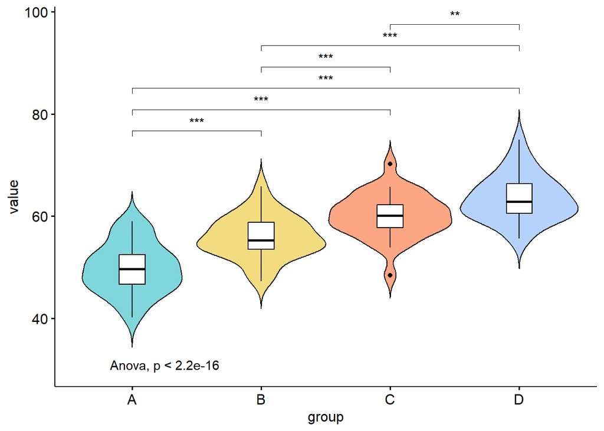

```r
# 设定显著性水平α=0.05
a <- 0.05

# 生成四组数据
set.seed(123)
groupA <- rnorm(30, mean = 50, sd = 5)
groupB <- rnorm(30, mean = 55, sd = 5)
groupC <- rnorm(30, mean = 60, sd = 5)
groupD <- rnorm(30, mean = 64, sd = 5)

# 数据框整理
dat <- data.frame(
  value = c(groupA, groupB, groupC, groupD),
  group = factor(rep(c("A", "B", "C", "D"), each = 30))
)

# 单因素ANOVA..............................................................................
# 1. 正态性检验（每组），
# 使用Shapiro-Wilk检验、Lilliefors检验、Anderson-Darling检验
normtest1 <- tapply(dat$value, dat$group, stats::shapiro.test)
normtest2 <- by(dat$value, dat$group, nortest::lillie.test)
normtest3 <- by(dat$value, dat$group, nortest::ad.test)
# 结果如下，所有组p>a，表明全不拒绝H0，都服从正态分布
# > normtest1
# $A
#   Shapiro-Wilk normality test
# data:  X[[i]]
# W = 0.97894, p-value = 0.7966
# $B
#   Shapiro-Wilk normality test
# data:  X[[i]]
# W = 0.98662, p-value = 0.9614
# $C
#   Shapiro-Wilk normality test
# data:  X[[i]]
# W = 0.98085, p-value = 0.8478
# $D
#   Shapiro-Wilk normality test
# data:  X[[i]]
# W = 0.97106, p-value = 0.5685
# > normtest2
# $A
#   Lilliefors (Kolmogorov-Smirnov) normality test
# data:  X[[i]]
# D = 0.091059, p-value = 0.7587
# $B
#   Lilliefors (Kolmogorov-Smirnov) normality test
# data:  X[[i]]
# D = 0.097828, p-value = 0.6559
# $C
#   Lilliefors (Kolmogorov-Smirnov) normality test
# data:  X[[i]]
# D = 0.079714, p-value = 0.8968
# $D
#   Lilliefors (Kolmogorov-Smirnov) normality test
# data:  X[[i]]
# D = 0.10226, p-value = 0.5864
# > normtest3
# dat$group: A
#   Anderson-Darling normality test
# data:  dd[x, ]
# A = 0.19951, p-value = 0.873
# --------------------------------------------------------------------------
# dat$group: B
#   Anderson-Darling normality test
# data:  dd[x, ]
# A = 0.20978, p-value = 0.8471
# --------------------------------------------------------------------------
# dat$group: C
#   Anderson-Darling normality test
# data:  dd[x, ]
# A = 0.22672, p-value = 0.7984
# --------------------------------------------------------------------------
# dat$group: D
#   Anderson-Darling normality test
# data:  dd[x, ]
# A = 0.31171, p-value = 0.5322

# 2. 方差齐性检验，使用Bartlett检验或Levene检验或Fligner-Killeen检验
homogvar1 <- stats::bartlett.test(value ~ group, data = dat)#Bartlett检验，要求数据正态分布
homogvar2 <- rstatix::levene_test(value ~ group, data = dat)#Levene检验，适用于非正态数据
homogvar3 <- car::leveneTest(value ~ group, data = dat)     #同上
homogvar4 <- stats::fligner.test(value ~ group, data = dat) #Fligner-Killeen检验，基于中位数，不依赖正态
# 结果如下，所有方法p>a，表明不能拒绝H0，认为满足方差齐次性
# > homogvar1
#   Bartlett test of homogeneity of variances
# data:  value by group
# Bartlett's K-squared = 0.82355, df = 3, p-value = 0.8438
# > homogvar2
# # A tibble: 1 × 4
#     df1   df2 statistic     p
#   <int> <int>     <dbl> <dbl>
# 1     3   116     0.418 0.741
# > homogvar3
# Levene's Test for Homogeneity of Variance (center = median)
#        Df F value Pr(>F)
# group   3  0.4176 0.7407
#       116
# > homogvar4
#   Fligner-Killeen test of homogeneity of variances
# data:  value by group
# Fligner-Killeen:med chi-squared = 1.5412, df = 3, p-value = 0.6728

# 3. 满足前置条件，进行单因素ANOVA
model <- aov(value ~ group, data = dat)
# 结果如下，p<a，表明拒绝原假设，认为各组均值不相等
# > summary(model)
#              Df Sum Sq Mean Sq F value Pr(>F)
# group         3   3166  1055.5   52.14 <2e-16 ***
# Residuals   116   2348    20.2
# ---
# Signif. codes:  0 ‘***’ 0.001 ‘**’ 0.01 ‘*’ 0.05 ‘.’ 0.1 ‘ ’ 1
# 对结果的解释：
# + 自由度表明，组数为4，样本总数为120（3=4-1,116=120-4）
# + Residuals表示残差，在ANOVA中，指组内的差异
# + 组间：平方和Sum Sq为3166.455，除以自由度DF，等于Mean Sq1055.5
# + 组内：平方和为2348.143，自由度116，均方为20.2
# + F统计量为52.14，p值小于2e-16，说明在0.05显著性水平下，拒绝原假设，认为各组均值不全相等
# + 至此可以判断至少有一组均值不等，但具体是哪一组，需进一步用多重比较进行检查

# 4. 事后检验（即多重比较），其作用是在ANOVA拒绝H0的情况下，检验哪些组之间存在显著差异
# 可选以下几种方法
# + TukeyHSD检验 (Tukey's Honest Significant Difference Test) （推荐）
# + LSD-t检验 (Least Significant Difference Test)
# + Dunnett-t检验
# + SNK-q检验 (Student-Newman-Keuls Test)
PHT_result1 <- stats::TukeyHSD(model)               #TukeyHSD检验
PHT_result2 <- PMCMRplus::lsdTest(model)            #LSD-t检验
PHT_result3 <- PMCMRplus::dunnettTest(model)        #Dunnett-t检验（只比较对照组）
PHT_result4 <- PMCMRplus::snkTest(model)            #SNK-q检验
# 结果如下，表明四组两两之间均值都不相同
# > PHT_result1
#   Tukey multiple comparisons of means
#     95% family-wise confidence level
# Fit: aov(formula = value ~ group, data = dat)
# $group
#          diff        lwr       upr     p adj
# B-A  6.127210  3.0990917  9.155329 0.0000037
# C-A 10.357621  7.3295020 13.385739 0.0000000
# D-A 13.766074 10.7379554 16.794193 0.0000000
# C-B  4.230410  1.2022915  7.258529 0.0022695
# D-B  7.638864  4.6107449 10.666982 0.0000000
# D-C  3.408453  0.3803346  6.436572 0.0207466
# 对结果的解释
# + TukeyHSD的H0是，第i组和第j组的均值相等
# + 它计算服从q分布（studentized range distribution）的studentized range统计量
# + TukeyHSD检验，控制了全局错误率，适合多组事后比较，相比之下如果两两进行t检验，容易引起多重比较问题使得整体第I类错误率（假阳性）上升
# > PHT_result2
#   Pairwise comparisons using Least Significant Difference Test
# data: value by group
#   A       B       C
# B 6.3e-07 -       -
# C 8.2e-15 0.00041 -
# D < 2e-16 1.5e-09 0.00403
# P value adjustment method: none
# alternative hypothesis: two.sided
# > PHT_result3
#   A
# B 1.5e-06
# C 1.5e-14
# D < 2e-16
# > PHT_result4
#   A       B       C
# B 6.3e-07 -       -
# C 5.6e-14 0.00041 -
# D 9.2e-15 4.4e-09 0.00403

# 5. 结果可视化，使用ggpubr包简化绘图
# 加载包
library(ggplot2)
library(ggpubr)
vars <- unique(dat$group) %>% as.vector()
varscomb <- combn(vars,2,simplify=F)
ggviolin(dat, x = "group", y = "value", fill = "group",
         palette = c("#00AFBB", "#E7B800", "#FC4E07", "#6EA8FD"), alpha=0.5,
         add = "boxplot", add.params = list(fill = "white"))+
  # 添加显著性标记，方法t.test、wilcox.test、anova等，comparisons时不能用anova
  stat_compare_means(
    comparisons = varscomb,
    method = "wilcox.test",
    symnum.args = list(cutpoints = c(0, 0.001, 0.01, 0.05, Inf),
                       symbols = c("***", "**", "*", "NS")),
    label = "p.signif")+
  # 添加全局P值标记，没有comparisons是全局的
  stat_compare_means(label.y = 30, method = "anova")+
  theme(legend.position = "none")
```